# Light

### Making a flashlight

Flashlights allow players to explore dark areas, creating tension as they explore their surroundings.

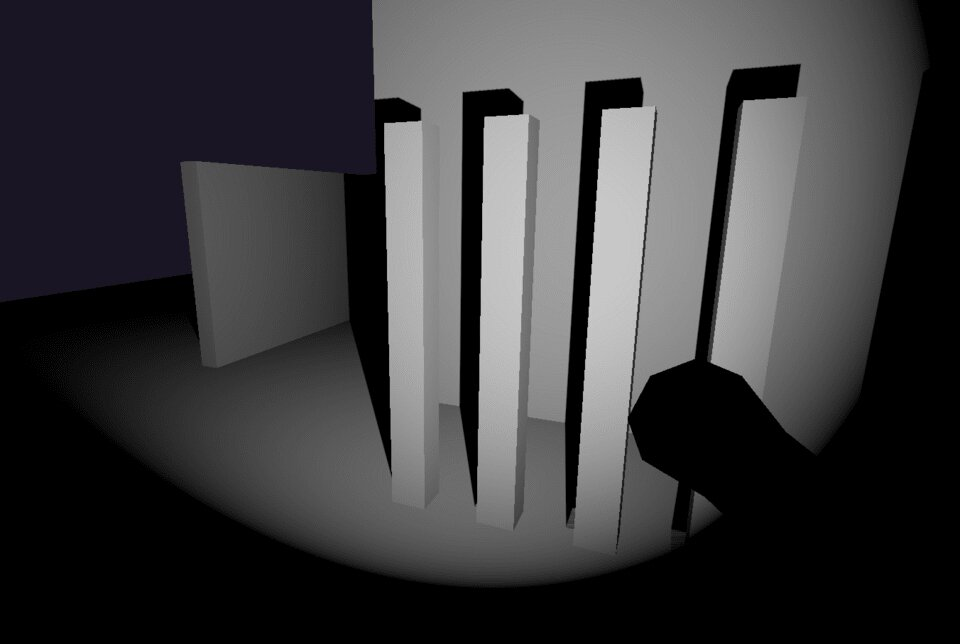

You can create dark scenes by adding a `WorldEnvironment` node and giving it an `Environment`. The default environment settings plunge the world into darkness.

[figure not shown]

Using an FPS character controller, we can parent a `MeshInstance` and a `SpotLight` onto the player’s `Camera` (or the parent node that it follows) to explore places in the dark.

You can turn the flashlight on or off using an `AnimationPlayer` to animate the light energy of the `SpotLight`.

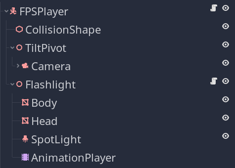

To make the shadows look more dramatic, we can offset the flashlight’s position and rotation to make the shadow angle stand out dramatically apart from the camera angle.

Lastly, enable shadows on the `SpotLight`. In Godot 3.x, spotlight shadows often appear to have bias problems unless you enable *Shadow -> Reverse Cull Face*.

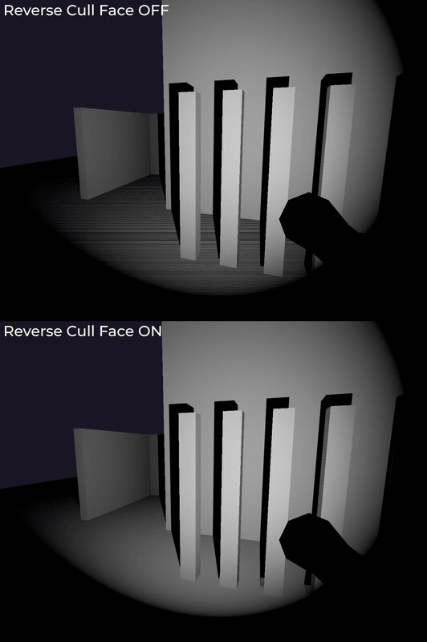

### Shooting out lights with a gun

Some games like *Thief* let you shoot out lights to hide your trail from patrolling enemies.

[figure not shown]

In Godot, you can make lights respond to player events using signals and collisions, which use an `AnimationPlayer` to change the light’s appearance once the event has occurred.

[figure not shown]

For the light bulbs, we used a `StaticBody` with a `CollisionShape`, `SpotLight`, and `AnimationPlayer`, so it registers as a physics body when the player’s gun `RayCast` hits it.

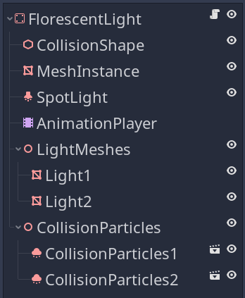

Our laser beam gun uses a `RayCast` node and checks for collisions when shooting. We use duck-typing to ensure the body has the `take_damage()` method. If so, we call the function.

```
    var target: Vector3
    var direction: Vector3
    if _camera_ray.is_colliding():
        var body = _camera_ray.get_collider()
        if body.has_method("take_damage"):
            body.take_damage()
        target = _camera_ray.get_collision_point()
        direction = target + _camera_ray.get_collision_normal()
    else:
        target = _camera_ray.to_global(_camera_ray.cast_to)
        direction = global_transform.origin
    _cast_beam(target, direction)
```

The body has a script to set up properties to animate groups of particles and switch the animation to “shot” instead of “idle.”

```
onready var _animation_player: AnimationPlayer = $AnimationPlayer
onready var _collision_particles: Spatial = $CollisionParticles
onready var _light_meshes: Spatial = $LightMeshes
onready var _spot_light: SpotLight = $SpotLight
```

Here’s the `take_damage()` function that gets called. The `AnimationPlayer` plays the “shot” animation once if it takes damage and ensures the light can’t play the animation twice.

```
func take_damage() -> void:
    if _is_broken:
        return

    _is_broken = true
    _animation_player.play("shot")
    for particles in _collision_particles.get_children():
        particles.emitting = true
```

If you’re instancing these lights as `.tscn` files like us, you may want to ensure the `Mesh` and its material are *Local To Scene*. Otherwise, all fluorescent lights animate at the same time, as they share the same `Mesh` resource.

You can split up the level mesh or increase the light limit in *Project Settings* with *Max Lights Per Object* at the cost of longer shader loading times.

### Triggering light on gunfire

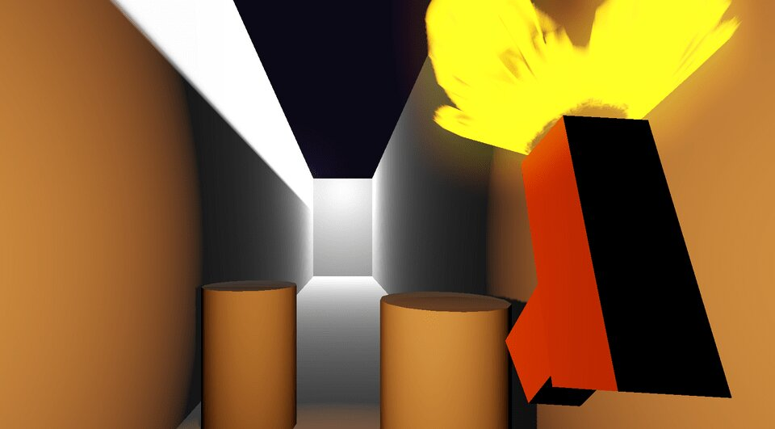

You can activate a light when shooting for added feedback and flair.

Using an `OmniLight`, you can animate the *Energy* property to make it flash. An `AnimationPlayer` is one way to animate the property, but a `Tween` is also a good fit.

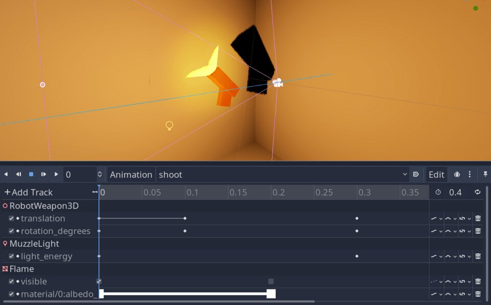

You can use an input action to restart the `AnimationPlayer`, triggering the light:

```
onready var _animation_player: AnimationPlayer = $Player/AnimationPlayer


func _unhandled_input(event: InputEvent) -> void:
    if event.is_action_pressed("shoot_3d"):
        _animation_player.stop(true)
        _animation_player.play("shoot")
```

If you want to learn more about making the gun shoot at objects, read the guide on RayCast nodes.

## Your questions

### What are the major differences between all the lighting options?

You’ll often combine light nodes like `OmniLight` with either `BakedLightmap` for low-end devices or `GIProbe` on high-end devices.

Here is a table comparing the different features of lighting options in Godot 3.x.

| Feature | Dynamic Lights | `BakedLightmap` | `GIProbe` |
| --- | --- | --- | --- |
| Updates at runtime | ✓ |  | ✓ |
| Supports indirect lighting |  | ✓ | ✓ |
| Runs well on low-end devices | ✓ | ✓ |  |
| Increases project file size |  | ✓ | ✓ |
| Renders real-time shadows | ✓ |  |  |

The main benefit of `BakedLightmap` over `GIProbe` is its low-performance cost. All baked lighting data gets saved as a texture. This increases file size fairly, but it runs well on older mobile devices or low-end computers.

`BakedLightmap` can also capture some lighting information about the game world to enhance your game’s look with dynamic objects at runtime. However, this can appear less accurate than the dynamic lighting provided by a `GIProbe` with low-quality settings.

### Which lighting option is best for my project?

`BakedLightmap` provides static, pre-rendered lighting. This is great for getting good-looking lighting on low-end GPUs, at the cost of larger file size to store the lightmap textures.

`GIProbe` provides real-time results but requires baking to get started, increasing the project file size. This is still less than what `BakedLightmap` requires. The main downside for `GIProbe` is that it’s hard to get good performance on low-end GPUs without sacrificing quality.

Dynamic lighting ( `OmniLight`, `DirectionalLight`, `SpotLight`) is fast on low-end GPUs with only a few lights.

You’re limited to `32` lights per surface. Levels that use more lights should split up the level meshes or increase the *Max Lights Per Object* in *Project Settings* at the cost of longer shader compile times.

If you want maximum performance, use `BakedLightmap` as much as possible, with dynamic lights and especially fewer lights casting shadows in real-time.

For more dynamic lighting, you can use the `GIProbe` node and combine lights. To ensure your game runs well, you’ll always have to test rendering performance on your project’s slowest target hardware.

### Where can I learn more about materials?

You can learn more about materials in our [free PBR Material Intro lesson.](https://www.gdquest.com/tutorial/godot/3d/pbr-material-intro/)

## Troubleshooting

### Shadow Issues

Suppose there’s a distance between your shadows and your objects. In that case, you can reduce the *Shadow Bias*, increase the *Contact* slider, or increase the available *Shadow Atlas Texture* size, so your shadows are more accurate to the space they’re trying to fill.

If you have lots of artifacts on `SpotLight` and `DirectionalLight`, enable *Reverse Cull Face*. It increases the distance between your mesh and the shadow, but it helps reduce banding.

Godot 4.0 plans to have improved real-time shadows that look sharper and more accurate without requiring as much adjusting.

### BakedLightmap Bugs

#### No lighting appears on my model after baking the scene

All bakeable meshes must come from an `ArrayMesh`. You can generate a second set of UV coordinates called UV2 to render light information to texture with these resources in the editor.

If a mesh doesn’t appear affected by `BakedLightmap`, you might still need to unwrap the UV2 in the *3D Toolbar*. After baking, you can check if `BakedLightmap` included your model by viewing the `.png` or `.exr` texture generated by the `BakedLightmap`.

#### Baking is taking forever

If you imported a mesh with a large scale, Godot gives it a lightmap size hint that matches the scale. The lightmap size hint won’t adjust to the new in-game scale if you scale the mesh down in Godot instead of your modeling software.

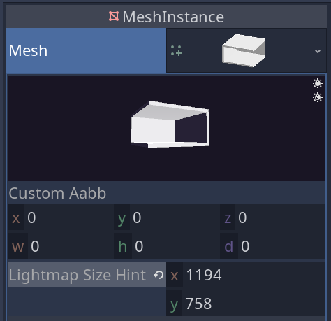

You can fix this by adjusting the lightmap size hint to a smaller value, like `64` on both axes.

#### Visible bands on baked lighting

If the baked light is banding, you can increase the *Dynamic Range* property, check *HDR*, or uncheck *Color*, so the banding is less noticeable.

If the baked light is super low-resolution and blocky, there are a few solutions:

- Minimize UV2 space for unbaked areas.
- Increase lightmap hint on the mesh.
- Don’t re-use baked meshes at wildly different scales. The light texture scales with the mesh, and if its resolution is too small, you’ll start to see stretched pixels.

#### Seams appear on the models

If you see seams on mesh corners, there are two solutions:

- Extend baked faces past their corners.
- Seal up the area behind the wall with solid light “blockers” set to bake.

### Dynamic Lighting Bugs

#### Too many lights in the scene

If there are too many lights in your scene, causing you to reach Godot’s limit, you have a few options:

Consider using `BakedLightmap` to bake light nodes that don’t move. For each light, set *Bake Mode -> All* instead of *Bake Mode -> Indirect* to free up the dynamic light budget.

Alternatively, use a single `DirectionalLight` to cover your level. Enabling shadows prevents this light from reaching interior spaces.

#### Dark blue low-contrast lighting

If there’s low-contrast lighting in your scene:

- Use a `WorldEnvironment`, and reduce *Ambient -> Sky Contribution*.
- Introduce a `DirectionalLight`.
- Use `BakedLightmap` or `GIProbe`.

## Pro Tips

You can get more accurate static lighting by sizing the *Extents* past the room’s geometry. This is an engine limitation as light beyond the extents is immediately cut off, leading to artifacts and dark spots.

The names of `GIProbe`, `BakedLightmap`, and `ReflectionProbe` are changing in Godot 4.0: https://github.com/godotengine/godot/pull/49325

If you’re casting long shadows using a `DirectionalLight`, you can reduce the *Shadow Max Distance* to free up more space on the shadow atlas. This leads to closer shadows appearing to look sharper. This only works because all real-time shadows share the same shadow atlas texture.

You can let Godot set the lightmap size hint for you to match Godot’s unit scale.

You can also adjust the lightmap size defaults in *Import* options.

Each model has a *Lightmap Size Hint*, which controls this, and can help improve or scale back on lightmap shadow quality for certain models.

A model’s lightmap hint contributes to the total size of the lightmap texture for each `BakedLightmap` node. If one model’s lightmap hint is huge, every other model fights for space within the data of a single `BakedLightmap` node.

This is where you can try to make trade-offs in lightmap quality between models, or up the texture resolution of the lightmap in the `BakedLightmap` properties, under *Atlas -> Max Size*.

You can turn off `BakedLightmap`’s *Capture* property if everything in your scene is static since it only lights dynamic objects to save file size.